# 2a Archetype Annotation

Annat Haber

2020-09-03

```r
knitr::opts_knit$set(root.dir = rprojroot::find_rstudio_root_file())
knitr::opts_chunk$set(cache=TRUE, cache.extra = R.version)
```

```r
suppressPackageStartupMessages({
  library(ggplot2)
  library(cowplot)
  library(Matrix)
  library(tidyverse)
  library(vcd)
  library(lattice)
})
```

This script examines whether any of the archetypes is enriched for a particular subtype or a clinical variable. It uses multi-way chi-square test and a plot of deviations from expectation for visualization. Sex is included as additional covariate with each of the clinical covariates. The Cochran-Mantel-Haenszel test tests for association between archetype and clinical covariate conditioned on sex, while the simple chi2 test considers all 3 factors equally. Width of bars in the plots reflect absolute numbers, while hight reflects deviation from expected values under the null hypothesis of no association.  
https://www.statmethods.net/stats/frequencies.html (and links within)

# Input

```r
# Loading all metadata including subtype and archetype data
archmeta <- readRDS("analyses/rnaseq/1_fit_archetypes/archetypes_meta_k3p20_AD.RDS")
```

# Classification to subtypes (k-mean clusters) compared with archetype

## Scatterplot of distances

Archetype 1 and 2 are closely related to subtype A  
Archetype 3 is closely related to subtype B

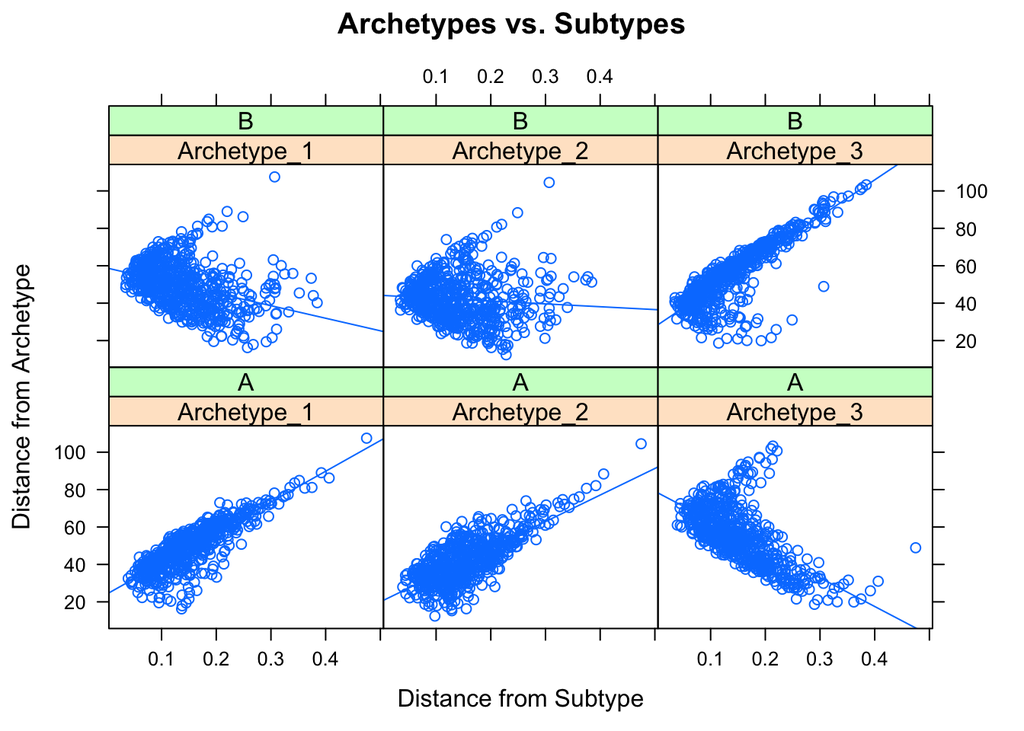

```r
# scatterplot of distances
n = nrow(archmeta)
dist.arch <- rep(c(archmeta$Archetype_1, archmeta$Archetype_2, archmeta$Archetype_3), 2)
dist.sub <- c(rep(archmeta$A, 3), rep(archmeta$B, 3))
arch <- rep(rep(1:3, each=n), 2) %>%
    factor(levels=1:3, labels=c("Archetype_1","Archetype_2","Archetype_3"))
sub <- rep(1:2, each=n*3) %>%
        factor(levels=1:2, labels=c("A","B"))

xyplot(dist.arch ~ dist.sub | arch*sub,
   main="Archetypes vs. Subtypes",
   ylab="Distance from Archetype", xlab="Distance from Subtype",
   type=c("p","r"))
```

## Chi2 test

```r
print(class.tab <- table(archmeta$Subtype, archmeta$Archetype))
```

```
##
##           Archetype_1 Archetype_2 Archetype_3
##   A                38          42           0
##   B                 9          29          34
##   Control          93         252         114
```

```r
names(dimnames(class.tab)) <- c("Subtype","Archetype")
summary(class.tab)
```

```
## Number of cases in table: 611
## Number of factors: 2
## Test for independence of all factors:
##  Chisq = 63.62, df = 4, p-value = 5.036e-13
```

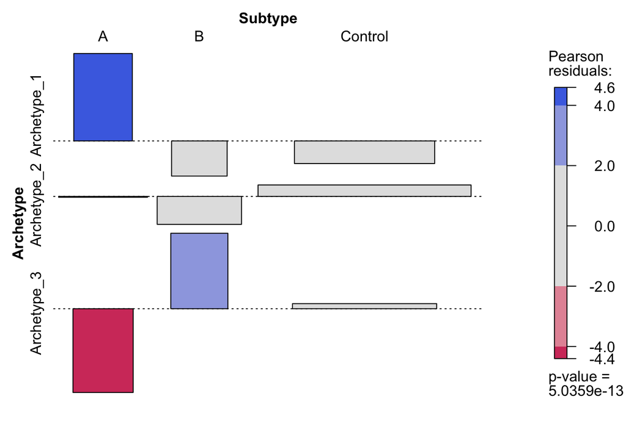

```r
assoc(Subtype ~ Archetype, class.tab, shade=TRUE)
```

Subtype B is highly over-represented in archetype 3  
Subtype A is highly over-represented in archetype 1  
Control and Other are somewhat over-represented in archetype 2 and under-represented in archetype 1

# Composition of Sex and clinical covariates in archetypes

## Sex

```r
data <- dplyr::select(archmeta, Sex, Archetype)
mytable <- xtabs(~ Archetype + Sex, data)
#ftable(mytable) # print table
summary(mytable) # chi-square test of indepedence
```

```
## Call: xtabs(formula = ~Archetype + Sex, data = data)
## Number of cases in table: 611
## Number of factors: 2
## Test for independence of all factors:
##  Chisq = 0.3606, df = 2, p-value = 0.835
```

```r
chisq.test(mytable) # non-significant when interaction is taken into account
```

```
##
##  Pearson's Chi-squared test
##
## data:  mytable
## X-squared = 0.36056, df = 2, p-value = 0.835
```

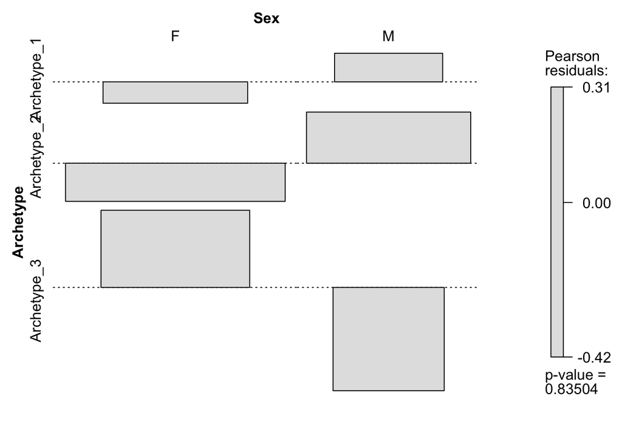

```r
assoc(mytable, shade=TRUE)
```

```r
pdf(file = "analyses/rnaseq/2a_archetypes_annotations/chi2_Sex.pdf")
assoc(mytable, shade=TRUE)
dev.off()
```

## Tissue diagnosis

The association between sex, diagnosis, and archetype is bordeline significant in the simple test but (borderline) non-significant when conditioned on sex.  
Males AD patients are under-represented and male control are over-represented in archetype 2.  
Both males and females are somewhat over-represented among AD patients and under-represented among control in archetype 1.  
Not much bias in archetype 3, nor among OTHER

```r
data <- dplyr::select(archmeta, Sex, Diagnosis, Archetype)
mytable <- xtabs(~ Archetype + Diagnosis + Sex, data)
#ftable(mytable) # print table
summary(mytable) # chi-square test of indepedence
```

```
## Call: xtabs(formula = ~Archetype + Diagnosis + Sex, data = data)
## Number of cases in table: 611
## Number of factors: 3
## Test for independence of all factors:
##  Chisq = 20.87, df = 12, p-value = 0.05232
```

```r
mantelhaen.test(mytable) # non-significant when interaction is taken into account
```

```
##
##  Cochran-Mantel-Haenszel test
##
## data:  mytable
## Cochran-Mantel-Haenszel M^2 = 9.3244, df = 4, p-value = 0.05348
```

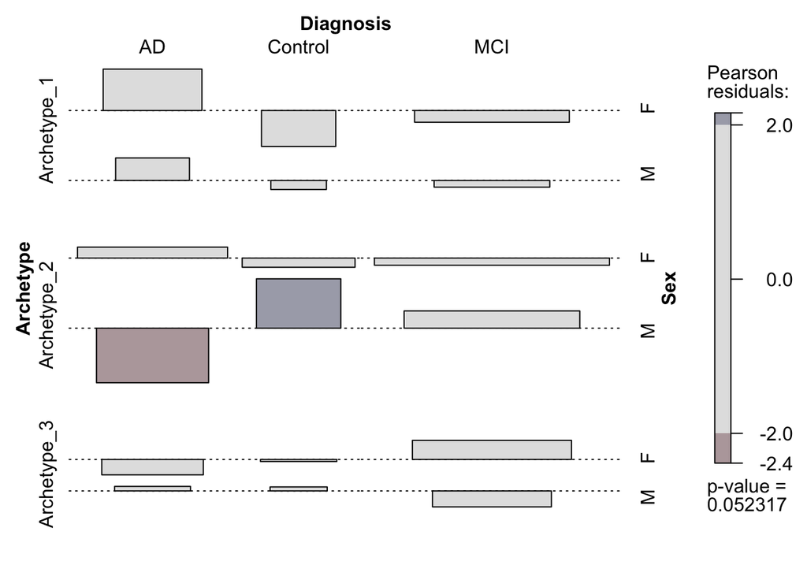

```r
assoc(mytable, shade=TRUE)
```

```r
pdf(file = "analyses/rnaseq/2a_archetypes_annotations/chi2_SexDx.pdf")
assoc(mytable, shade=TRUE)
dev.off()
```

## Cognitive diagnosis

Final clinical consensus diagnosis (from ROSAMP codebook):  
1-Control, 2-3-MCI, 4-5-AD, 6-Other dementia In accord with the above:  
The association between sex, diagnosis, and archetype is significant in the simple test but not when conditioned on sex.  
Male AD patients are under-represented in archetype 2.  
Female MCI’s are over-represented in archetype 3. Both male and female AD are somewhat over-represented in archetype 1 compared to control. Other dimentia is slightly over-represented in both males and females of archetype 1

```r
data <- dplyr::select(archmeta, Sex, Cognitive.Diagnosis, Archetype)
mytable <- xtabs(~ Archetype + Cognitive.Diagnosis + Sex, data)
#ftable(mytable) # print table
summary(mytable) # chi-square test of indepedence
```

```
## Call: xtabs(formula = ~Archetype + Cognitive.Diagnosis + Sex, data = data)
## Number of cases in table: 611
## Number of factors: 3
## Test for independence of all factors:
##  Chisq = 40.58, df = 22, p-value = 0.009234
##  Chi-squared approximation may be incorrect
```

```r
mantelhaen.test(mytable) # non-significant when interaction is taken into account
```

```
##
##  Cochran-Mantel-Haenszel test
##
## data:  mytable
## Cochran-Mantel-Haenszel M^2 = 12.414, df = 8, p-value = 0.1337
```

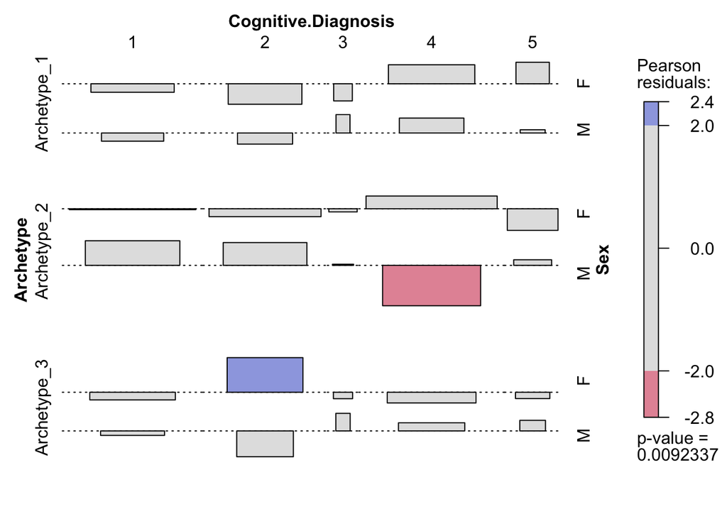

```r
assoc(mytable, shade=TRUE)
```

```r
pdf(file = "analyses/rnaseq/2a_archetypes_annotations/chi2_SexCogDx.pdf")
assoc(mytable, shade=TRUE)
dev.off()
```

## BRAAK score

A semiquantitative measure of neurofibrillary tangles (from ROSMAP codeboook and https://link.springer.com/article/10.1007%2FBF00308809):  
0 Control  
1-2 neurofibrillary tangle involvement is confined mainly to the transentorhinal region of the brain.  
3-4 there is also involvement of limbic regions such as the hippocampus.  
5-6 there is extensive neocortical involvement.  
The association between sex, braak score, and archetype is significant in both tests.  
Male control are highly over-represented in archetype 3 (consistent with being a “neronal” archetype?)  
As with cognitive diagnosis, male early stages are over-represented in archetype 2  
Later stages are slightly over-represented in archetype 1, especially females

```r
data <- dplyr::select(archmeta, Sex, Braak.Score, Archetype)
mytable <- xtabs(~ Archetype + Braak.Score + Sex, data)
#ftable(mytable) # print table
summary(mytable) # chi-square test of indepedence
```

```
## Call: xtabs(formula = ~Archetype + Braak.Score + Sex, data = data)
## Number of cases in table: 611
## Number of factors: 3
## Test for independence of all factors:
##  Chisq = 62.3, df = 32, p-value = 0.001051
##  Chi-squared approximation may be incorrect
```

```r
mantelhaen.test(mytable) # non-significant when interaction is taken into account
```

```
##
##  Cochran-Mantel-Haenszel test
##
## data:  mytable
## Cochran-Mantel-Haenszel M^2 = 22.911, df = 12, p-value = 0.02849
```

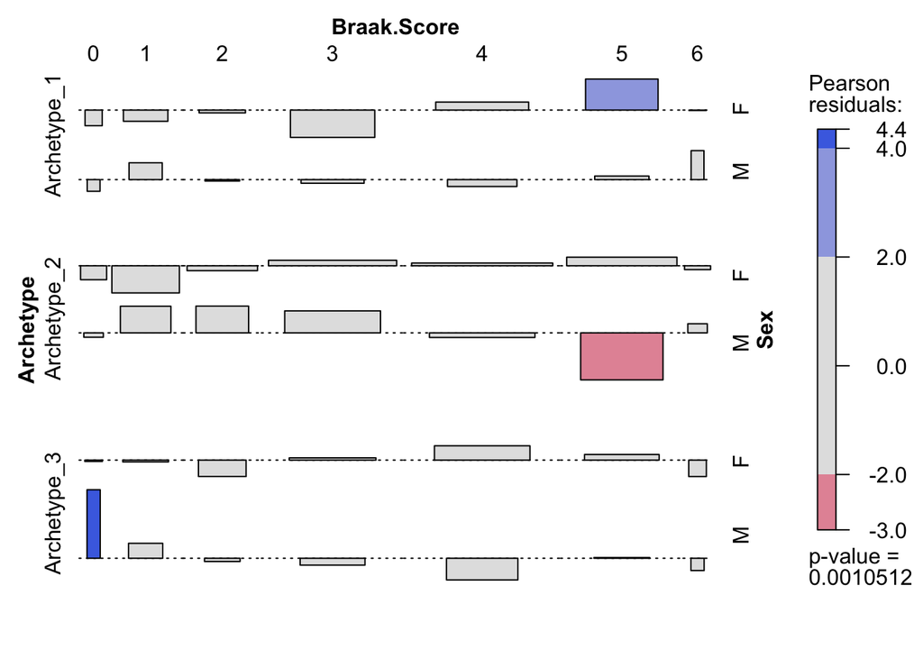

```r
assoc(mytable, shade=TRUE)
```

```r
pdf(file = "analyses/rnaseq/2a_archetypes_annotations/chi2_SexBraak.pdf")
assoc(mytable, shade=TRUE)
dev.off()
```

## CERAD score

A semiquantitative measure of neuritic plaques (from ROSMAP codeboook):  
1 Definitely AD  
2 Probable  
3 Possible  
4 No AD  
The association between sex, cerad score, and archetype is not significant in either tests.  
Yet, sex effect seems stronger here (p is lower when association is conditioned on sex in CMH test), so that female AD are over-represented in archetype 1 and male control are over-represented in archetype 2

```r
data <- dplyr::select(archmeta, Sex, CERAD.Score, Archetype)
mytable <- xtabs(~ Archetype + CERAD.Score + Sex, data)
#ftable(mytable) # print table
summary(mytable) # chi-square test of indepedence
```

```
## Call: xtabs(formula = ~Archetype + CERAD.Score + Sex, data = data)
## Number of cases in table: 611
## Number of factors: 3
## Test for independence of all factors:
##  Chisq = 19.77, df = 17, p-value = 0.2862
```

```r
mantelhaen.test(mytable) # non-significant when interaction is taken into account
```

```
##
##  Cochran-Mantel-Haenszel test
##
## data:  mytable
## Cochran-Mantel-Haenszel M^2 = 10.501, df = 6, p-value = 0.1051
```

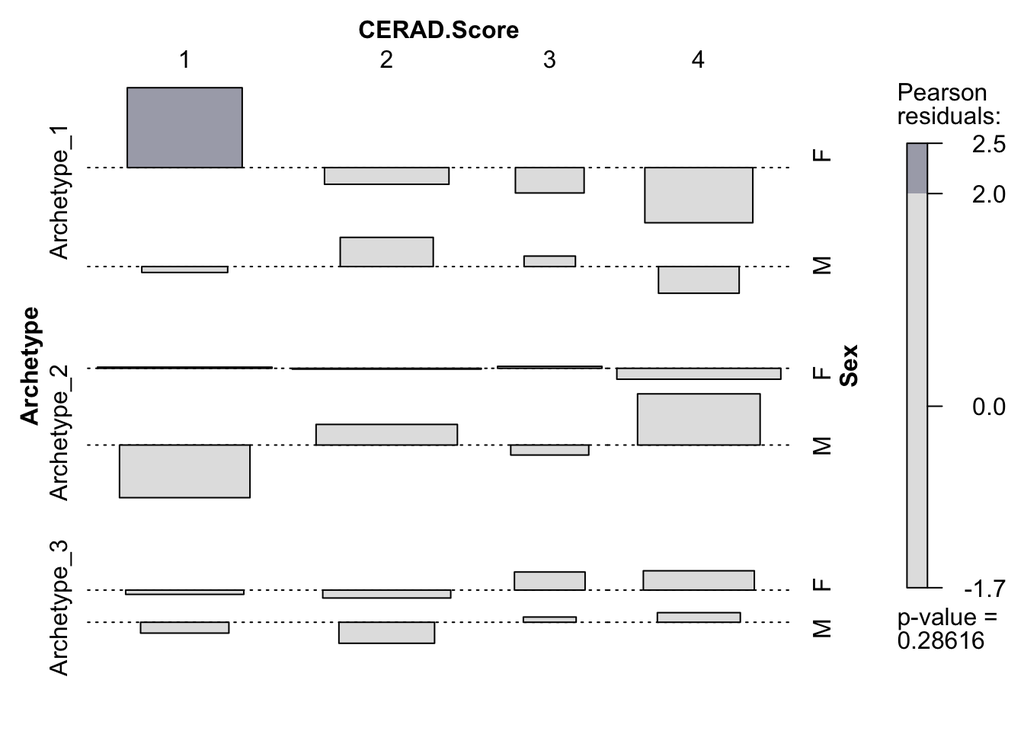

```r
assoc(mytable, shade=TRUE)
```

```r
pdf(file = "analyses/rnaseq/2a_archetypes_annotations/chi2_SexCerad.pdf")
assoc(mytable, shade=TRUE)
dev.off()
```

## APOE4 status

0 homozygote or heterozygote w/o e4  
1 heterozygote e4 with any other  
2 homozygote e4  
The association between sex, apoe4, and archetype is not significant in either tests.  
Female homozygote e4 are slightly over-represented in archetype 1 in accord with the above findings (female AD later stages are over-represented in archetype 1 based on cogDx, braak, and cedar).  
**brake down 0 to reflect other genotypes?**

```r
data <- dplyr::select(archmeta, Sex, APOE4, Archetype)
mytable <- xtabs(~ Archetype + APOE4 + Sex, data)
#ftable(mytable) # print table
summary(mytable) # chi-square test of indepedence
```

```
## Call: xtabs(formula = ~Archetype + APOE4 + Sex, data = data)
## Number of cases in table: 610
## Number of factors: 3
## Test for independence of all factors:
##  Chisq = 31.604, df = 27, p-value = 0.2471
##  Chi-squared approximation may be incorrect
```

```r
mantelhaen.test(mytable) # non-significant when interaction is taken into account
```

```
##
##  Cochran-Mantel-Haenszel test
##
## data:  mytable
## Cochran-Mantel-Haenszel M^2 = 13.11, df = 10, p-value = 0.2176
```

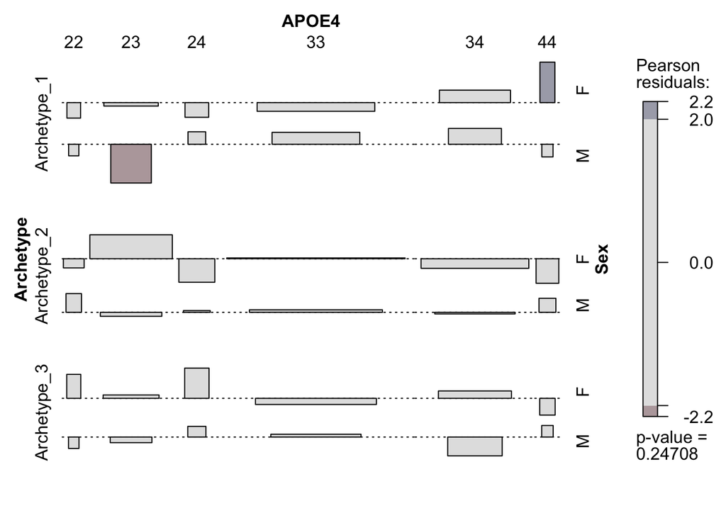

```r
assoc(mytable, shade=TRUE)
```

```r
pdf(file = "analyses/rnaseq/2a_archetypes_annotations/chi2_SexApoe4.pdf")
assoc(mytable, shade=TRUE)
dev.off()
```

# Pseudotime

Looks like archetype_3 (neuronal is an earlier stage, archetype_2 (olygo_astro; cell function) is in between, archetype_1 (inflammation) is a later stage

```r
pst <- read_csv("data/rna_rosmap_pseudotime.csv") # Syn17023795
```

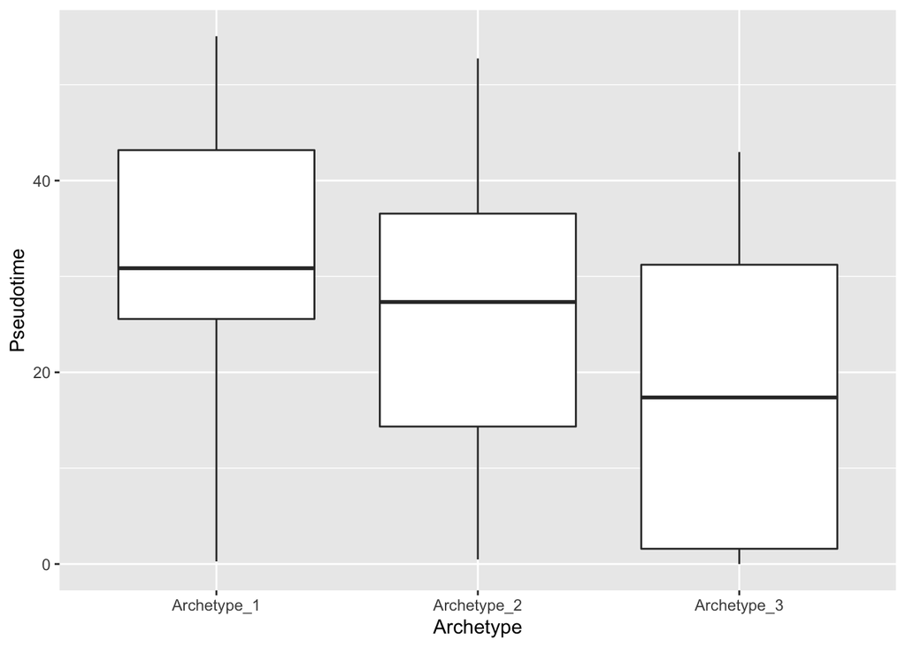

```r
pstm <- merge(archmeta, pst, by.x="rnaseq_id", by.y="SampleID") %>%
  dplyr::select(rnaseq_id, Diagnosis, Archetype, Archetype_1, Archetype_2, Archetype_3, Pseudotime)


ggplot(pstm) +
  geom_boxplot(aes(Archetype, Pseudotime))
```

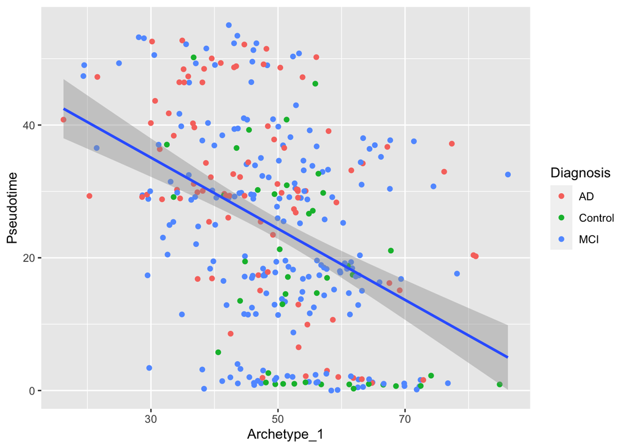

```r
ggplot(pstm, aes(Archetype_1, Pseudotime)) +
  geom_point(aes(color=Diagnosis)) +
  geom_smooth(method = "lm", se = TRUE)
```

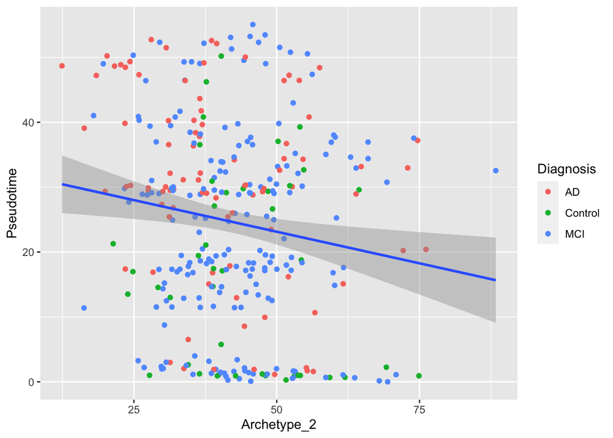

```r
ggplot(pstm, aes(Archetype_2, Pseudotime)) +
  geom_point(aes(color=Diagnosis)) +
  geom_smooth(method = "lm", se = TRUE)
```

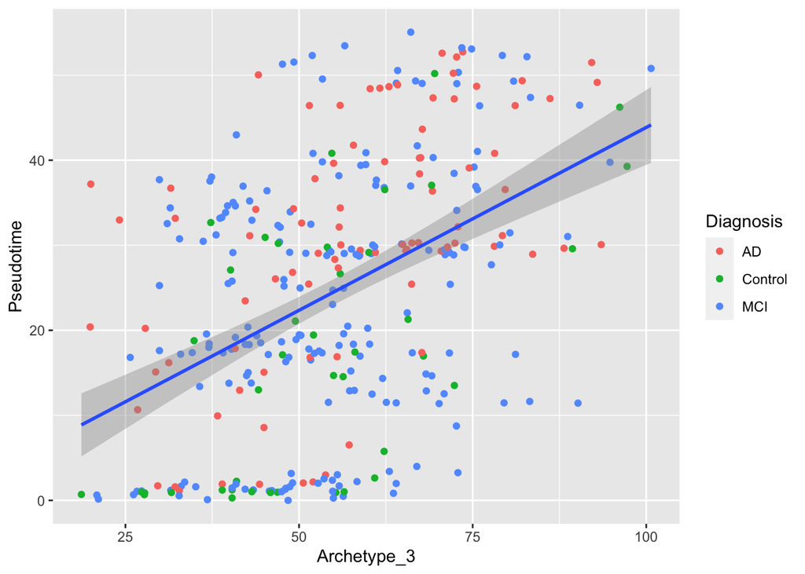

```r
ggplot(pstm, aes(Archetype_3, Pseudotime)) +
  geom_point(aes(color=Diagnosis)) +
  geom_smooth(method = "lm", se = TRUE)
```